# Build Regression Models

DA5020 / Regression 11.1

Larkin, Yvonne

Sp 2025, April 2nd

```r
suppressPackageStartupMessages(library(knitr))
suppressPackageStartupMessages(library(TTR))
suppressPackageStartupMessages(library(dplyr))
```

## Load the CSV data into R

```r
wine_df <- read.csv("https://s3.us-east-2.amazonaws.com/artificium.us/datasets/wine-quality-data.csv")
```

The wine data is loaded as *wine_df* has 7 columns headed: fixed.acidity, residual.sugar, pH, sulphates, alcohol, quality, type

## Outliers

### Visually Review those Identified

```r
#identify outliers, and look at results
numeric_cols <- sapply(wine_df, is.numeric)
for( i in 1:length(numeric_cols)){
  #only numeric columns evaluated
  if(numeric_cols[i] == TRUE){
    #find mean and standard deviation for current column
    m <- mean(wine_df[,i], na.rm = TRUE)
    s <- sd(wine_df[,i], na.rm = TRUE)
    #find outlier as defined by z-score above 3.0
    outliers <- which(abs((wine_df[,i] - m) / s)>3.0)
    #print results to view
    if (length(outliers) > 0) {
      ## found outliers; view before deciding what to do to them
      cat("Found ",length(outliers), " outliers in column '", names(wine_df)[i], "': \n")
      cat(" category average : ", m, " sd : ", s, "   --> ", wine_df[outliers,i], "\n\n")
    }
  }
}
```

```
## Found  128  outliers in column ' fixed.acidity ':
##  category average :  7.215307  sd :  1.296434    -->  11.2 11.5 12.8 12.8 11.6 12 15 15 12.5 11.8 11.5 11.5 11.5 11.4 12 11.6 13.3 11.6 13.4 11.9 12.4 12.5 12.2 11.9 13.8 13.5 11.5 11.9 12.6 11.9 12.5 12.8 12.8 14 11.5 11.5 11.4 13.7 13.7 12.7 12 11.5 11.5 12.2 11.4 12 12.5 11.9 12.8 11.9 12.3 12…
##
## Found  26  outliers in column ' residual.sugar ':
##  category average :  5.443235  sd :  4.757804    -->  20.7 20.7 22 22 19.8 20.8 19.8 23.5 31.6 31.6 19.95 19.95 20.4 65.8 20.2 20.2 19.8 19.8 20.15 19.95 19.9 26.05 26.05 20.8 20.3 22.6
##
## Found  33  outliers in column ' pH ':
##  category average :  3.218463  sd :  0.1608175    -->  3.9 3.75 3.85 3.74 3.72 3.9 3.71 3.71 3.71 3.78 3.78 4.01 4.01 3.71 3.72 3.72 3.72 3.72 3.72 3.82 3.81 3.77 3.74 2.72 3.8 3.79 3.74 3.8 3.77 3.76 3.75 3.75 3.76
##
## Found  75  outliers in column ' sulphates ':
##  category average :  0.5312683  sd :  0.1488059    -->  1.56 1.28 1.08 1.2 1.12 1.28 1.14 1.95 1.22 1.95 1.98 1.31 2 1.08 1.59 1.02 1.03 1.61 1.09 1.26 1.08 1 1.36 1.18 0.98 1.13 1.04 1.11 1.13 0.99 1.07 1.06 1.06 1.05 1.06 1.04 1.05 1.02 1.14 0.99 1.02 1.36 1.36 1.05 1.17 1.62 1.06 1.18 1.07 0.9…
##
## Found  1  outliers in column ' alcohol ':
##  category average :  10.51078  sd :  1.970872    -->  137
##
## Found  35  outliers in column ' quality ':
##  category average :  5.818378  sd :  0.8732553    -->  3 3 3 3 3 3 3 3 3 3 3 3 3 3 3 9 9 9 3 9 3 3 3 3 9 3 3 3 3 3 3 3 3 3 3
```

### ‘fixed.acidity’

I tinkered with the data few different ways: general outliers identified above, outliers based on wine type (red, rose, white), and where only the outliers based on type were replaced for “red”.

### ‘alcohol’

There is only one outlier and it appears to be a missed decimal upon data entry so we with infer that the correct entry would be 13.7 instead of 137.

### ‘quality’

This category appears to be a wine rating that is not an inherent trait of the wine but a deduced score from wine tasters. Therefore none of the ratings should be viewed as outliers because it is more of a subjective quality.

```r
#handle each category

# 'fixed.acidity' by type drastically changes which are outliers
# 128 outliers not separated by type, reset variables
m <- mean(wine_df[,"fixed.acidity"], na.rm = TRUE)
s <- sd(wine_df[,"fixed.acidity"], na.rm = TRUE)
#find outlier as defined by z-score above 3.0
outliers <- which(abs((wine_df$fixed.acidity - m) / s)>3.0)
wine_df$fixed.acidity[outliers] <- NA_integer_

# 'residual.sugars' do seem to be outliers, replace with NA
for(i in 1:nrow(wine_df)){
  #re-set valuesfor residual sugar mean and sd
  m <- mean(wine_df[,"residual.sugar"])
  s <- sd(wine_df[,"residual.sugar"])
  wine_df$residual.sugar[which(abs((m - wine_df[i,"residual.sugar"]) / s)>3.0)] <- NA_integer_
}

# 'pH' outliers are tightly grouped together and still in the same ranking for pH as the mean so ignore them as outliers, google also said pH of wine is 3-4 where sparkling can be higher

# 'sulphates' these are higher and don't look like an entry error so will remove
# make NA and replace with respective imputed values after
for(i in 1:nrow(wine_df)){
  #re-set values for sulphate mean and sd
  m <- mean(wine_df[,'sulphates'], na.rm = TRUE)
  s <- sd(wine_df[,'sulphates'], na.rm = TRUE)
  #replace outliers
  wine_df$sulphates[which(abs((m - wine_df[i,"sulphates"]) / s)>3.0)] <- NA
}

# singular 'alcohol' outlier seems like a user input error, move decimal
wine_df$alcohol[which(wine_df$alcohol == 137)] <- 13.7

#quality seems to be a observed rating from 1 to 10, so none are outlier values by nature, leave alone
```

## Missing Values

There were explicit instructions to impute the median value for a category filtered by the wine type. These missing values are any outliers reassigned to *NA_integer* and any missing values originally in the data set (if any).

```r
# median based on type of wine
num_Rows <- nrow(wine_df)
num_Cols <- ncol(wine_df)
# set found to false
found <- F
for(i in 1: num_Cols){
  missingValues <- which (is.na(wine_df[,i]) | wine_df[,i] == "")
  numMV <- length(missingValues)
  if(numMV > 0){
    print(paste0("Column '", names(wine_df)[i], "' has ", numMV, " missing values"))
    # set found to true, to prevent print statement where no missing values
    found <- T
  }
}
```

```
## [1] "Column 'fixed.acidity' has 128 missing values"
## [1] "Column 'residual.sugar' has 1 missing values"
## [1] "Column 'pH' has 4 missing values"
## [1] "Column 'sulphates' has 1 missing values"
```

```r
# no missing values, found still false
if(!found){
  print("no missing values detected")
}
```

```r
# all columns except type are numeric, and type has no missing values ,so treat all numerically
for(i in 1:num_Cols){
  #find median values by type
  median_red <- median(wine_df[which(wine_df[,"type"] == "red"), i], na.rm = TRUE)
  median_rose <- median(wine_df[which(wine_df[,"type"] == "rose"), i], na.rm = TRUE)
  median_white <- median(wine_df[which(wine_df[,"type"] == "white"), i], na.rm = TRUE)
  #replace missing values with median, no missing type values so won't impact with NA
  missingValues <- which(is.na(wine_df[,i]))
  wine_df[missingValues, i] <- ifelse(wine_df[missingValues, "type"]== "red", median_red, ifelse(wine_df[missingValues, "type"]== "rose", median_rose, median_white))
}
```

## One-hot Encoding

There are 3 types of wine: red, rose, and white. Because of this 2 new columns need to be added to the data frame where we can assign binary code to the columns where 1 indicates TRUE and 0 indicates FALSE. The last type of wine is an implied value of all zeros and not listed in the data frame but still part of the linear modeling later. The column “type” in the wine_df was left in the data frame but not included in the modeling.

```r
#three options, not binary so need to make new columns where there is one less than the category types and where 1 = TRUE and 0 = FALSE
n <- nrow(wine_df)
#initialize columns
wine_df$red <- 0
wine_df$rose <- 0
#loop through
for(i in 1:n){
  if(wine_df$type[i] == "red")
    wine_df$red[i] <- 1
  else if(wine_df$type[i] == "rose")
    wine_df$rose[i] <- 1
}
```

## Full Regression Model with all Features

```r
#use all features to predict wine quality in regression model
wine_model <- lm(quality ~ fixed.acidity + residual.sugar + pH + sulphates + alcohol + red + rose, data = wine_df)
summary(wine_model)
```

```
##
## Call:
## lm(formula = quality ~ fixed.acidity + residual.sugar + pH +
##     sulphates + alcohol + red + rose, data = wine_df)
##
## Residuals:
##     Min      1Q  Median      3Q     Max
## -3.4949 -0.4965 -0.0355  0.4855  3.0981
##
## Coefficients:
##                 Estimate Std. Error t value Pr(>|t|)
## (Intercept)     1.554689   0.291199   5.339 9.67e-08 ***
## fixed.acidity  -0.002591   0.011317  -0.229    0.819
## residual.sugar  0.021678   0.002345   9.244  < 2e-16 ***
## pH              0.046460   0.072025   0.645    0.519
## sulphates       0.706083   0.073565   9.598  < 2e-16 ***
## alcohol         0.352646   0.008740  40.347  < 2e-16 ***
## red            -0.246377   0.031643  -7.786 7.99e-15 ***
## rose            0.135707   0.271540   0.500    0.617
## ---
## Signif. codes:  0 '***' 0.001 '**' 0.01 '*' 0.05 '.' 0.1 ' ' 1
##
## Residual standard error: 0.7671 on 6489 degrees of freedom
## Multiple R-squared:  0.2292, Adjusted R-squared:  0.2284
## F-statistic: 275.7 on 7 and 6489 DF,  p-value: < 2.2e-16
```

## Step-Wise Elimination

### ‘fixed.acidity’

This overall highest category is ‘fixed.acidity’ and is removed from the following model. It does not significantly impact the other variable probabilities, overall model significance, or $R^2$ values. Continue to remove next variable with largest p-value.

```r
# fixed.acidity is the next highest p-value
wine_model <- lm(quality ~ residual.sugar + pH + sulphates + alcohol + red + rose, data = wine_df)
summary(wine_model)
```

```
##
## Call:
## lm(formula = quality ~ residual.sugar + pH + sulphates + alcohol +
##     red + rose, data = wine_df)
##
## Residuals:
##     Min      1Q  Median      3Q     Max
## -3.4964 -0.4965 -0.0362  0.4866  3.0921
##
## Coefficients:
##                 Estimate Std. Error t value Pr(>|t|)
## (Intercept)     1.511907   0.223339   6.770  1.4e-11 ***
## residual.sugar  0.021693   0.002344   9.254  < 2e-16 ***
## pH              0.054071   0.063890   0.846    0.397
## sulphates       0.704720   0.073318   9.612  < 2e-16 ***
## alcohol         0.352773   0.008722  40.446  < 2e-16 ***
## red            -0.249898   0.027654  -9.037  < 2e-16 ***
## rose            0.135014   0.271504   0.497    0.619
## ---
## Signif. codes:  0 '***' 0.001 '**' 0.01 '*' 0.05 '.' 0.1 ' ' 1
##
## Residual standard error: 0.767 on 6490 degrees of freedom
## Multiple R-squared:  0.2292, Adjusted R-squared:  0.2285
## F-statistic: 321.7 on 6 and 6490 DF,  p-value: < 2.2e-16
```

### ‘rose’

“Rose” category’s high p-value implyies it is not significantly different from the “white” category, which is implied into the model. But “red” is significant and with keeping at least one of the hot-one encoded categories it will keep the implied as well. “Rose” category is removed from the following model.

However, this still does not significantly impact the other variable probabilities, overall model significance, or $R^2$ values. Continue to remove next variable with largest p-value.

```r
# rose is the next highest p-value, which would imply not significantly different from white but red is
wine_model <- lm(quality ~ residual.sugar + pH + sulphates + alcohol + red, data = wine_df)
summary(wine_model)
```

```
##
## Call:
## lm(formula = quality ~ residual.sugar + pH + sulphates + alcohol +
##     red, data = wine_df)
##
## Residuals:
##     Min      1Q  Median      3Q     Max
## -3.4967 -0.4963 -0.0350  0.4864  3.0919
##
## Coefficients:
##                 Estimate Std. Error t value Pr(>|t|)
## (Intercept)     1.509312   0.223265   6.760  1.5e-11 ***
## residual.sugar  0.021694   0.002344   9.255  < 2e-16 ***
## pH              0.054843   0.063868   0.859    0.391
## sulphates       0.704968   0.073312   9.616  < 2e-16 ***
## alcohol         0.352794   0.008722  40.451  < 2e-16 ***
## red            -0.250248   0.027643  -9.053  < 2e-16 ***
## ---
## Signif. codes:  0 '***' 0.001 '**' 0.01 '*' 0.05 '.' 0.1 ' ' 1
##
## Residual standard error: 0.767 on 6491 degrees of freedom
## Multiple R-squared:  0.2292, Adjusted R-squared:  0.2286
## F-statistic:   386 on 5 and 6491 DF,  p-value: < 2.2e-16
```

### ‘pH’

The next variable with the highest p-value left in the model is “pH”. Removal from the following model still does not significantly impact the other variable probabilities, overall model significance, or $R^2$ values. Continue to remove next variable with largest p-value.

```r
# pH is the next highest p-value that is the last above 0.05
wine_model <- lm(quality ~ residual.sugar + sulphates + alcohol + red, data = wine_df)
summary(wine_model)
```

```
##
## Call:
## lm(formula = quality ~ residual.sugar + sulphates + alcohol +
##     red, data = wine_df)
##
## Residuals:
##     Min      1Q  Median      3Q     Max
## -3.4914 -0.4968 -0.0383  0.4860  3.0938
##
## Coefficients:
##                 Estimate Std. Error t value Pr(>|t|)
## (Intercept)     1.678507   0.104993  15.987   <2e-16 ***
## residual.sugar  0.021435   0.002324   9.222   <2e-16 ***
## sulphates       0.707195   0.073265   9.653   <2e-16 ***
## alcohol         0.353386   0.008694  40.647   <2e-16 ***
## red            -0.244834   0.026914  -9.097   <2e-16 ***
## ---
## Signif. codes:  0 '***' 0.001 '**' 0.01 '*' 0.05 '.' 0.1 ' ' 1
##
## Residual standard error: 0.767 on 6492 degrees of freedom
## Multiple R-squared:  0.2291, Adjusted R-squared:  0.2286
## F-statistic: 482.3 on 4 and 6492 DF,  p-value: < 2.2e-16
```

### Regression Equation

Based on the above model (last of the step-wise elimination) we can build a regression model from the “Coefficients” table based on the variable’s corresponding “Estimate”. The “estimate” gives us the slope for the corresponding variable and the starting intercept.

```r
#assign to variables for markdown
wine_lm_coeff <- wine_model$coefficients
intercept <- round(wine_lm_coeff[1],2)
slope1 <- round(wine_lm_coeff["residual.sugar"],2)
slope2 <- round(wine_lm_coeff["sulphates"],2)
slope3 <- round(wine_lm_coeff["alcohol"],2)
slope4 <- round(wine_lm_coeff["red"],2)
#implied slope of 0 for white
```

## Regression Equation:

$$\hat{y} = 1.68 + (0.02*\text{residual.sugar}) + (0.71*\text{sulphates})
+ (0.35*\text{alcohol}) + (-0.24*\text{red}) + (0*\text{white})$$

## Root Mean Squared Error (RMSE)

Overall, the RMSE indicates model performance and is interpreted in the dependent variables units. So depending on the scale, is how the number should be interpreted. Because, it basically tells you how far a prediction is from the actual observation.

```r
mse <- mean((wine_df$quality - predict(wine_model))^2)
rmse <- sqrt(mse)
```

The wine model’s RMSE is 0.77. The quality rating seems to be a scale of 1 to 10 but the range we observe is a minimum of 3 to a maximum of 9. It would appear to be a moderate to fair prediction depending on the overall scale interpretation. But for the sake fo data in the file having a range of 6, I would say it is a more moderate given the low $R^2$ value in the linear model.

## New Wine Prediction

Given the wine parameters: fixed.acidity = 7.3, residual.sugar = 1.84, pH = 3.67, sulphates = 0.49, alcohol = 8.6, type = “white”

We can evaluate with the above regression equation that represents our model.

```r
new_wine <- data.frame(residual.sugar = 1.84,
                       sulphates = 0.49,
                       alcohol = 8.6,
                       red = 0)
result <- predict(wine_model, new_wine)
```

The evaluated quality score for the wine is 5.1.

## Confidence Interval

```r
resultCI <- predict(wine_model, new_wine, interval = "confidence")
```

The 95% confidence interval for the derived model is: 5.0536778 and 5.15

## Evaluation of Distribution

Based on the following histogram, QQ plot, and Shapiro-Wilks test it would generally *appear* to be a normal distribution but we would overall conclude that the data is **not** normally distributed. This is because the following histogram is skewed slightly to the right for the main distribution but you can see more tappering left.

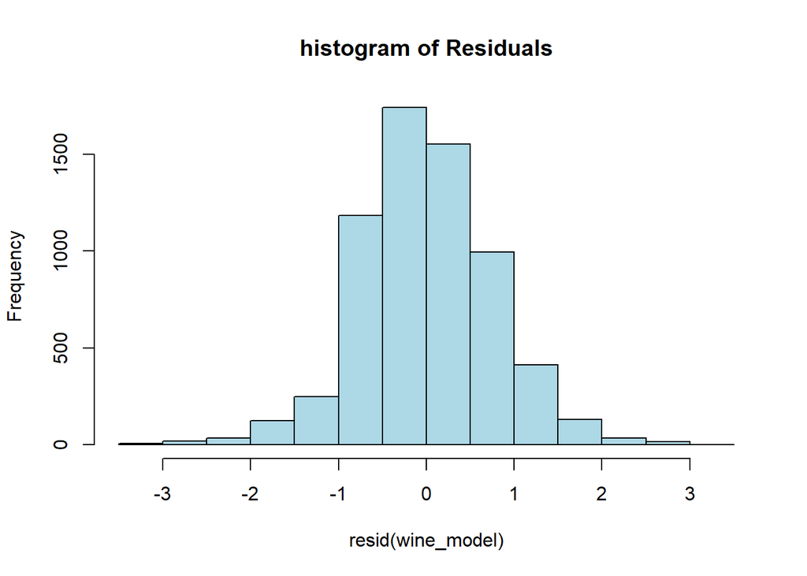

```r
hist(resid(wine_model), main = "histogram of Residuals", col = "lightblue")
```

Both tails of the QQ plot deviate from the line, and the ideal normal distribution QQ plot would be a 45 degree angle.

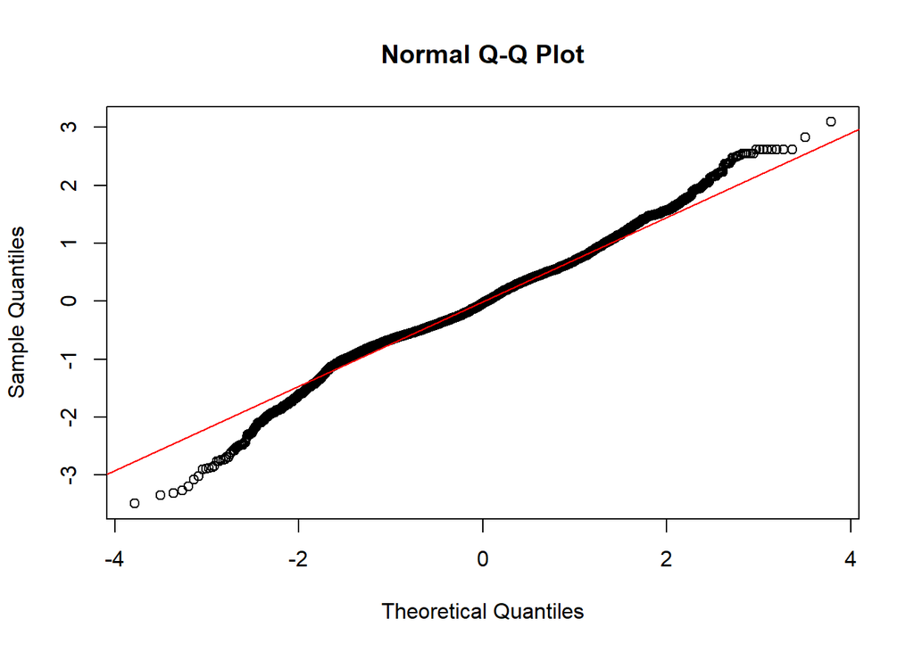

```r
qqnorm(resid(wine_model))
qqline(resid(wine_model), col = "red")
```

Lastly, while the W value for the Shapiro Wilks test is very close to 1 indicating it is probably normally distributed. The p value is below the standard 0.05 cut off threshold which would say we reject the null hypothesis of Shapiro Wilks that says the data is normally distributed.

```r
all_residuals <- resid(wine_model)
#subsample of 5000 as mas limit for shapiro wilks test
#no replacement because want unique values
resid_sample <- sample(all_residuals, size = 5000, replace = FALSE)
shapiro.test(resid_sample)
```

```
##
##  Shapiro-Wilk normality test
##
## data:  resid_sample
## W = 0.98785, p-value < 2.2e-16
```

So overall, I would say the data is not normally distributed.